# Wordclouds, Lexical Dispersion and STM

Kara Brick

10/2/2020

```r
library(tufte)
```

I borrowed heavily from the Caleb’s blog: *https://blog.paperspace.com/intro-to-datascience/* to set up a wordcloud, the most visually appealing and straightforward of the qualitative data visualization, in my opinion. For this example, I will be using data from a set that I have been working on and am familiar with: interviews from after a workshop that took place with a group teachers in Liberia. Liberians speak Liberian English, and that is not the same as what we speak, but I think most of the stopwords are the same.

Start out by installing quanteda and RColorBrewer. I’m adding pander and dplyr because they will be useful, also. I’m setting my path here, too, in the knitr chunk.

```r
knitr::opts_chunk$set(root.dir = normalizePath("~/Desktop/CPP527"))

library(RColorBrewer)
library(pander)
library(dplyr)
```

Next I will load the data from excel by Importing in in R. I will now rename my dataset as raw, because the name is lengthy.  
The data can be separated by interviewee. Some of the language is different, and the cells represent answers that have already been split up into conveniant chunks for longhand qualitative coding.

“My role as a teacher is to make sure I teach our incoming generation well” - DC This data is from excel, so it is a dataframe. I saved is as a csv file and had to make sure that all of the text from the interviews were in one cell in excel, and that those cells had a label that I could call for the text_field when creating a corpus in quanteda.  
We will start the use of quanteda by putting the data into the form of a corpus.  
Quanteda needs to read the text and transform it into a corpus. So, we need packages quanteda and readtext. Understanding how to accurately format these commands and the paths to get to them was what took me the most time on this.  
The text I am using does not necessarily have docvars - or document variables. The only variable assigned here is the Interviewee. I chose to use raw data for this one because getting into the structure of quanteda copora with excel files with qualitative codes of my own making seems too confusing for this code-through, and it helps me understand the functions better. When you look at the summary of my corpus, it is easy to see what I am talking about - there are ten documents (the interviews). There aren’t dates, interviewers, hashtags or topics, like you might find with other useful texts.

A good resource for understanding quanteda from the bottom up is from the University of Virginia Library: *https://data.library.virginia.edu/a-beginners-guide-to-text-analysis-with-quanteda/*  
Below I am importing my data, assigning a text_field and naming my documents after the interviewee initials.

```r
library(quanteda)
library(readtext)
dat_inT <- read.csv(paste0("/Users/karabrick/Desktop/CPP527/IN.DAT.csv"))
int.corpus <- corpus(dat_inT, text_field = "Interview")
docnames(int.corpus) <- int.corpus$"Interviewee"
summary(int.corpus)
```

```
## Corpus consisting of 10 documents, showing 10 documents:
##
##  Text Types Tokens Sentences Interviewee
##    TW   542   3217       171          TW
##    BO   496   2614       189          BO
##    MM   641   3429       253          MM
##    HF   764   4805       154          HF
##    EN   496   2614       189          EN
##    DC   496   2614       189          DC
##    CS   502   2600       182          CS
##    CY   496   2614       189          CY
##   CY2   496   2614       189         CY2
##    TM   552   2894       199          TM
```

I had to take out a few more stopwords - ‘yeah’ and ‘okay’ which makes me laugh. I guess Liberian English utilizes these words more, because the first time I did it they were front and center in my word cloud.

This is what my code ended up looking like to get a wordcloud. By the way, I had to do some funny stuff with the r calls at the top of r chunks to make it a full image in Tufte’s layout. You can also make images appear in the margin.

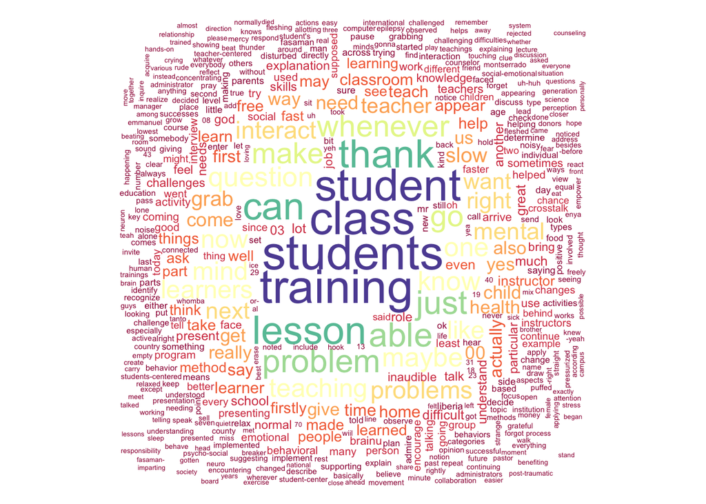

```r
#WordCloud
IC.col <- brewer.pal(11, "Spectral")
IC.cloud <- int.corpus %>%
  dfm(remove = c('yeah', 'okay',stopwords('english')), remove_punct = TRUE) %>%
    dfm_trim(verbose = FALSE)

set.seed(100)
textplot_wordcloud(max_size = 4, IC.cloud, color = IC.col)
```

You can adjust word clouds by size, number of words, nice color scales in color brewer, etc. Below I set the rotation to zero, so that all the words would be horizontal.

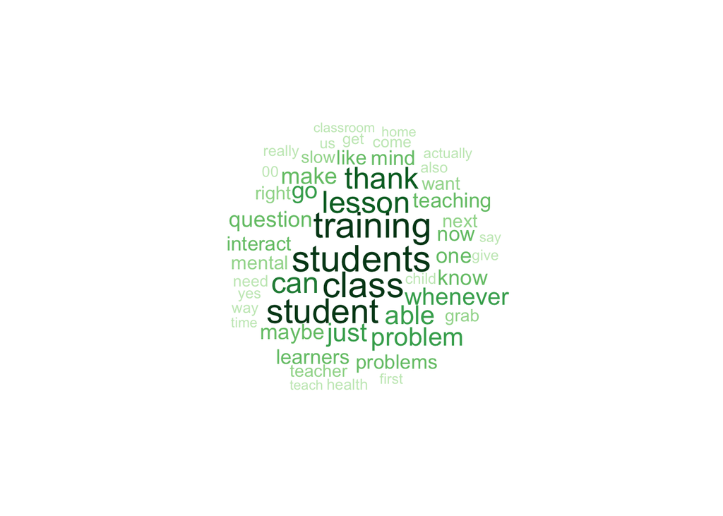

```r
IC.col <- brewer.pal(9, "Greens")
IC.cloud <- int.corpus %>%
  dfm(remove = c('yeah', 'okay',stopwords('english')), remove_punct = TRUE) %>%
    dfm_trim(verbose = FALSE)

set.seed(100)
textplot_wordcloud(max_size = 3, max_words = 50, rotation = 0, IC.cloud, color = IC.col)
```

A note on Color Brewer for R Markdown: You see where I circled the letters? Where the arrow is pointing? That is your R language. When you are selecting a color scheme, those are the letters you need for your brewer.pal function.

Each color palette has a maximum and a minimum number of colors. This is the first argument we call in our function brewer.pal. If you put the wrong number, your wordcloud will still generate with an errror directing you to change the number to the correct maximum number.

[figure not shown]

You can check out Tufte magic here: *http://rstudio.github.io/tufte/envisioned/*. You can also open a Tufte template in a new R markdown file in R.

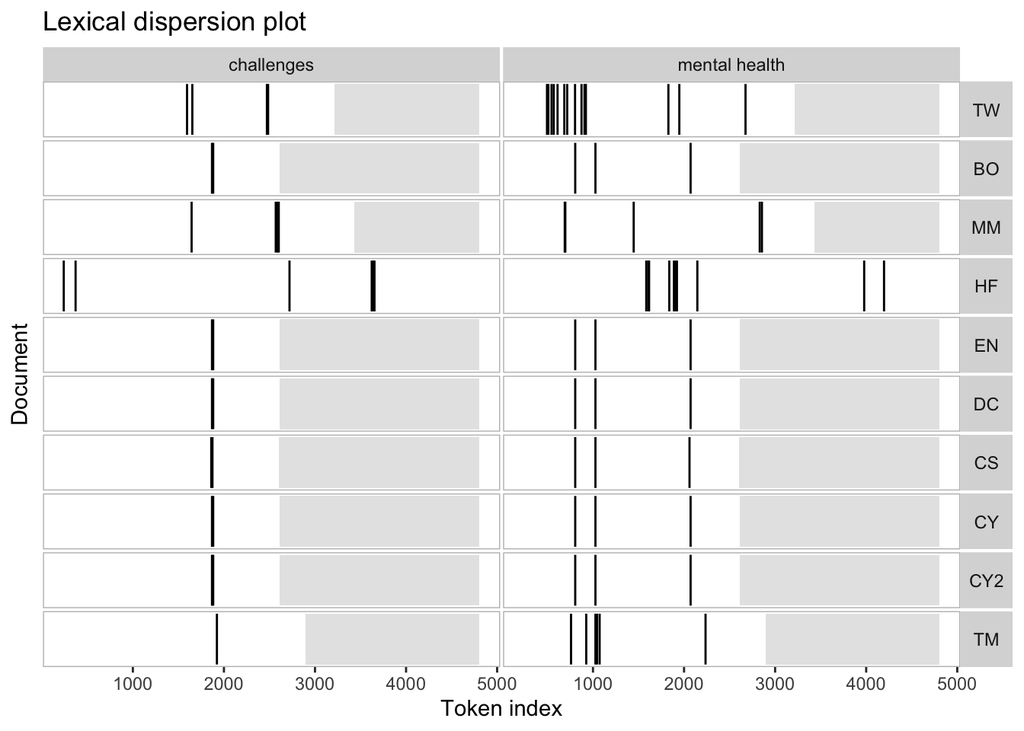

```r
int.corpus_low <- char_tolower(int.corpus)

kwic(int.corpus_low, pattern = c("challenges", phrase("mental health"))) %>%
    textplot_xray(scale = "absolute")
```

Another cool function of kwic is words in context. For instance, I can choose a word, such as student, and ask kwic to bring up phrases around that word, with the ‘window’ argument being the number of words before or after that word.

```r
head(kwic(int.corpus_low, "student", window = 4))
```

[output not shown]

In this section I will put my corpus into a document feature matrix (DFM), a useful class for quanteda.  
From here we can look at a list of tokens, or words, by frequency.

```r
int.corpus_dfm <- dfm(int.corpus, remove_punct = TRUE, remove = c('yeah', 'okay', 'first', stopwords('english'), stem = TRUE))
head(int.corpus_dfm, nf = 50)
```

```
## Document-feature matrix of: 6 documents, 50 features (29.3% sparse) and 1 docvar.
##     features
## docs question role class room teacher thank impart knowledge unto students
##   TW        6    2    26    3      16    20      3        11    2       48
##   BO       10    2    17    0       3    15      0         1    0       14
##   MM        9    3     8    2      12    13      0         1    0       11
##   HF       10    8     9    0      11    13      0         7    0       25
##   EN       10    2    17    0       3    15      0         1    0       14
##   DC       10    2    17    0       3    15      0         1    0       14
## [ reached max_nfeat ... 40 more features ]
```

But wait! Apparently DFMs should be tokenized before becoming DFMs.

```r
this.tokens.in <- tokens(int.corpus,
                     remove_numbers = TRUE,
                     remove_separators = TRUE,
                     remove_punct = TRUE)
this.tokens.in<- tokens_select(this.tokens.in, stopwords('english'), selection='remove')
this.tok.in.dfm <- this.tokens.in %>% dfm(remove = 'okay')
```